# Lecture 3: The Basics

# Exceptions and Errors

### What is Coding (Mostly) About?

*99 little bugs in the code,*

*99 bugs in the code,*

*1 bug fixed...run again,*

*100 little bugs in the code...*

Coding and data analysis is a continuous trial and error

- You are going to do multiple mistake for each operation you want to do
  - Very stressful at first, be committed and patient with yourself
- We will now briefly talk about how to approach de-bugging and the available options to deal with exceptions (errors, warnings, etc.)

## Computer Bugs

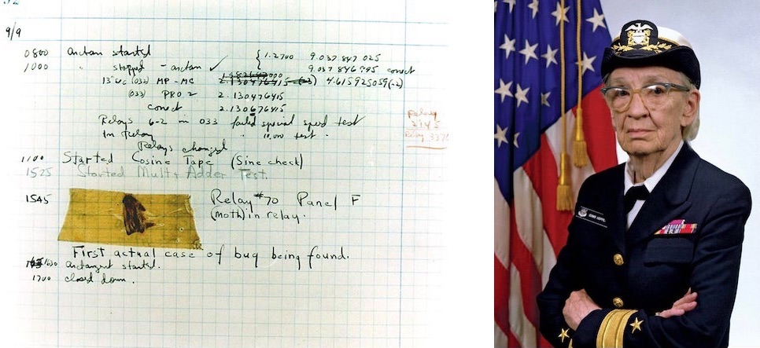

The actual first computer bug. On September 9, 1947, Admiral Grace Hopper found this moth trapped on a relay of the Harvard Mark II computer. (Image source: U.S. Naval Historical Center Online Library)

### How to Debug:

1. Try Avoiding bugs in the first place
   - Start with very simple statments
   - Always print intermediate results
     - Very often what you think should be the output and the real output are different (**90% of beginners errors are here!**)
   - Use descriptive names for variables
2. External resources/Learn from Other Programmers: Use **Google/Stackoverflow/Github/AI** to better understand and find a solution to your problem

### Debugging Systematically

1. Use **`print()`** to investigate what is inside your variables at crucial steps
   - Compare input in successful and failing runs - **START SIMPLE!!!**
   - Formulate a hypothesis on the location of the problem
   - Design an experiment and test the hypothesis using `print()`
   - Keep record of your experiment (so you can re-check in case)
   - Repeat

### Getting Info From The Error

When a Python script fails, usually it will raise an exception

- The console will display the *traceback* with the information on the cause of the exception
  - Detailing the chain of function calls leading to the error
  - Somewhere in that chain there is the problem
- Use `%xmode` (*exception mode*) to control the amount of information printed when the exception is raised

Before seeing a simple example, let's introduce the family of `%xmode` magic commands:

### IPython Magic Commands

- IPython entails *magic commands* that are prefixed by the `%` character
- Magic commands succinctly solve various common problems in data analysis, they come in two flavors:
  - *line magics*, prefixed by a single `%`, that operate on a single line of input
  - *cell magics*, prefixed by a double `%%`, that operate on multiple lines of inputs
- There are many, we only review a couple to get an idea

### Two functions

Here we define two functions:

```python
def func1(x):
    a = x
    b = x - 1
    return func2(a, b)

def func2(a, b):
    return a / b
```

### Controlling Exceptions: `%xmode`

```python
func1(1)
```

```
---------------------------------------------------------------------------
ZeroDivisionError                         Traceback (most recent call last)
Cell In[18], line 1
----> 1 func1(1)

Cell In[17], line 4, in func1(x)
      2 a = x
      3 b = x - 1
----> 4 return func2(a, b)

Cell In[17], line 7, in func2(a, b)
      6 def func2(a, b):
----> 7     return a / b

ZeroDivisionError: division by zero
```

### Default Traceback

```python
%xmode Plain
func1(1)
```

```
Exception reporting mode: Plain
```

```
Traceback (most recent call last):

  Cell In[19], line 2
    func1(1)

  Cell In[17], line 4 in func1
    return func2(a, b)

  Cell In[17], line 7 in func2
    return a / b

ZeroDivisionError: division by zero
```

With `Plain` we no longer see the code where the exception is raised

```python
%xmode Verbose
func1(1)
```

```
Exception reporting mode: Verbose
```

```
---------------------------------------------------------------------------
ZeroDivisionError                         Traceback (most recent call last)
Cell In[20], line 2
      1 get_ipython().run_line_magic('xmode', 'Verbose')
----> 2 func1(1)

Cell In[17], line 4, in func1(x=1)
      2 a = x
      3 b = x - 1
----> 4 return func2(a, b)
        a = 1
        b = 0

Cell In[17], line 7, in func2(a=1, b=0)
      6 def func2(a, b):
----> 7     return a / b
        a = 1
        b = 0

ZeroDivisionError: division by zero
```

Using the `Verbose` option we also have the information on the values of variables

### Error information

The extra information can help you understand why the exception is being raised

Which traceback option is best depends on the complexity of the code you are debugging

- `Verbose` provides a lot of information but the traceback can get extremely long
- Depending on the context, the brevity of `Plain` or `Context` may be easier to work with.

### Debugging: When Reading Tracebacks Is Not Enough

The IPython-enhanced version of this is `ipdb`, the IPython debugger.

- This debugger lets you step through the code line by line
- Many ways to launch/usee the debuggers
  - The most convenient interface to debugging is the `%debug` magic command
  - Refer to the online documentation to learn more
- If you run `%debug` after an exception is raised, it will open an interactive debugging prompt at the point of the exception.
- The `ipdb` prompt lets you explore the current state of the stack (the "pile" of commands that you have sent to be executed), explore the available variables, and even run Python commands!
  - Out of the scope of this course but a powerful tool that you need to know exists

### After Debugging for Hours...

- Stop
- Try commenting your code or explaining it to someone else
- Sleep on it

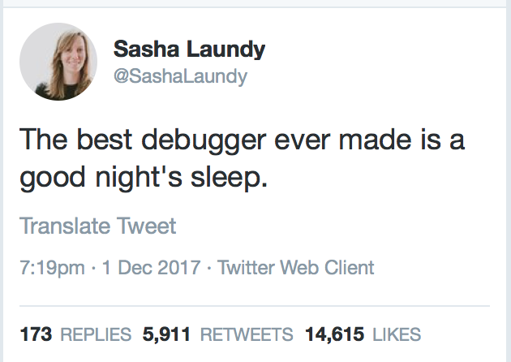

(Image source: Reddit)

### Debugging with AI

- What AI can do
  - Explain error messages and traceback in plain language
  - Suggest likely causes and concrete fixes (code patches, parameter changes)
  - Propose debugging steps (print checks, assert statements, logging)
- Best practices when asking an AI
  - Provide your code and the error output
  - Ask for multiple hypotheses and a prioritized list of fixes

### Debugging with AI

- Limitations & safety
  - Validate any AI-suggested change locally and with tests — do not apply blindly
  - Be careful sharing sensitive data (private data, login information) in prompts
  - Combine AI suggestions with human review and automated tests
- Workflow once you get an error
  1. copy the input and output (error message, traceback)
  2. Ask AI for explanations, hypotheses, and patches
  3. If you do not like the answer, generate a minimal reproducible example to put on SO
  4. Apply changes incrementally and run tests
  5. Review and document the fix

### Homework

- Set up the project folder, including the subfolders

### Notes

**Book references:**  
Ch.2 of [Python for Data Analysis](https://wesmckinney.com/book/)  
Ch.1 of [Python Data Science Handbook](https://jakevdp.github.io/PythonDataScienceHandbook/)

**Office Hours:**  
See on my [website](http://www.dgdi.me/#teaching)

**Author:** Duccio Gamannossi degl'Innocenti  
[Web: https://www.dgdi.me/](https://www.dgdi.me/)  
Mail: duccio.gamannossi@unipd.it